# Climate and the Earth’s Biomes

## Current vs Collective state of the atmosphere

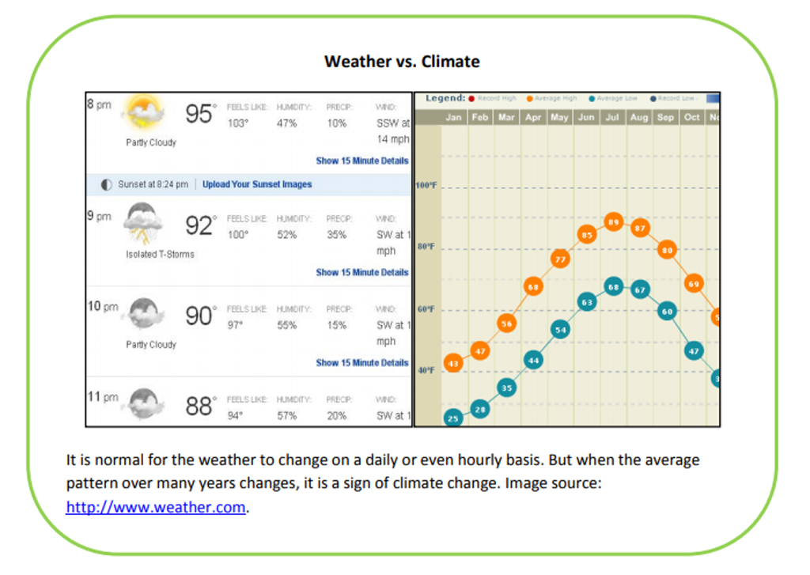

## Atmospheric elements of climate and weather

- **Precipitation**
  - process that ends with the fall of water to the earth’s surface.
- **Temperature**
  - amount of heat energy in the air
- **Atmospheric pressure**
  - force exerted on a surface by the weight of the atmosphere.
  - varies vertically; decreases as air ascends
  - influences the movement of air
- **Wind**
  - dries humidity, causes storms, and drives evaporation
- **Solar radiation**
  - provides heat
- **Cloudiness**
  - form when humid air cools to dew point & water/ice attaches to dust, ash, etc.
  - type and # are important

## Climate vs Weather: Words matter

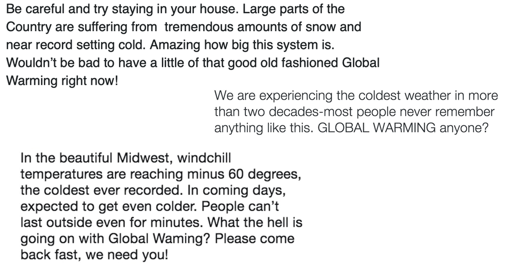

## The Earth is divided into different climate zones

**Distinguished by several key physical biosphere features**

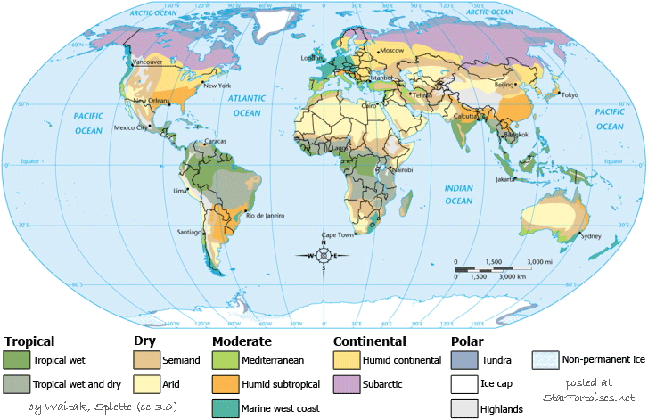

## Slope of Earth’s surface causes uneven heating across latitudes

[figure not shown]

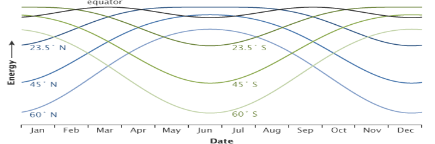

## Earth’s axial tilt (23.5°) and orbit creates seasons

**More uneven heating**

[figure not shown]

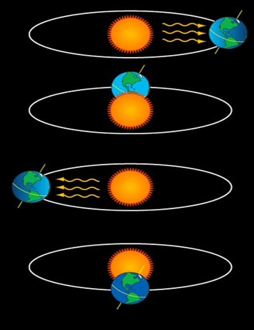

## Atmosphere circulation creates large climate patterns

**Creates wet and dry regions on land surfaces**

[figure not shown]

[figure not shown]

## Earth’s atmosphere contains six rotating cells

**Coriolis effect (from spinning earth) deflects cells in different directions above/below equator**

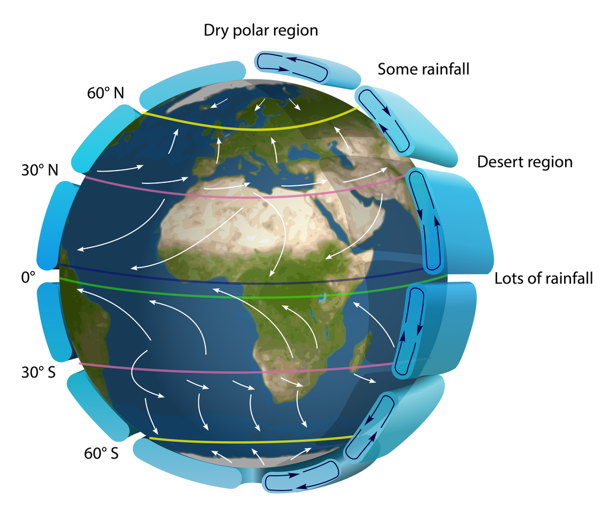

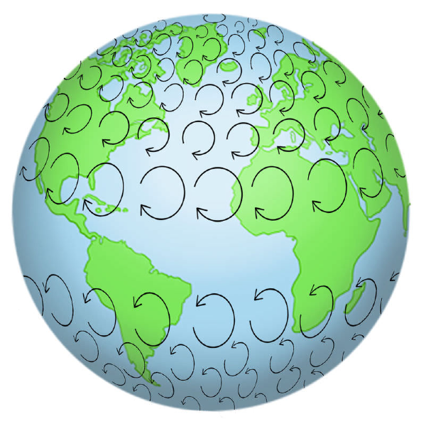

## Earth surface features also impact climate

**Weather and climate do not just happen to a landscape…**

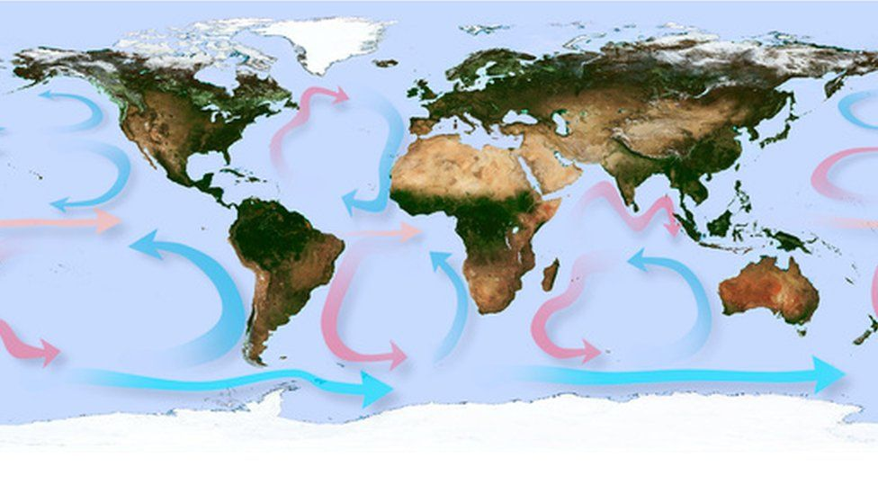

## Mountains and the rain shadow effect

[figure not shown]

## Closeness to large bodies (remember the water cycle)

[figure not shown]

## Surface features also impact weather: Atlantic hurricanes

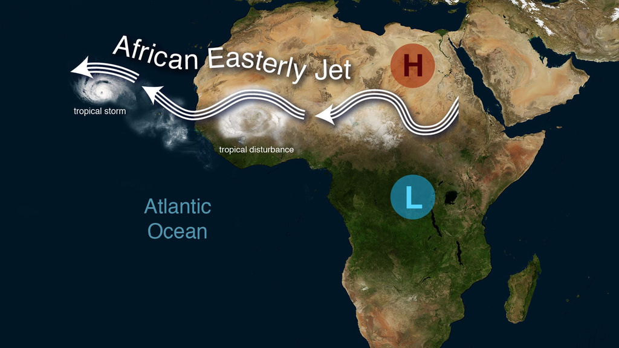

## Surface features impact weather: Atlantic hurricanes

[video not shown]

## Vegetation alters weather and climate

**Trees pull water from the ground and release water vapor through their leaves, generating atmospheric rivers of moisture in tropical ‘rain’ forests**  
https://www.youtube.com/watch?v=Y3OWgb0Bv-A

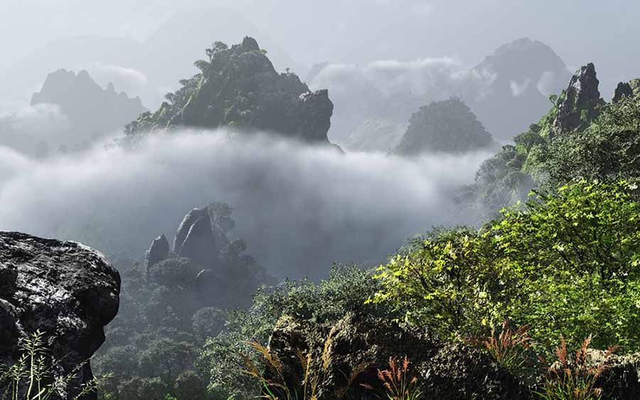

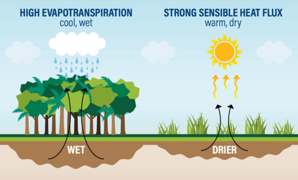

## Why is London warmer than Boston in the winter?

[figure not shown]

## Ocean currents heavily impact global climates

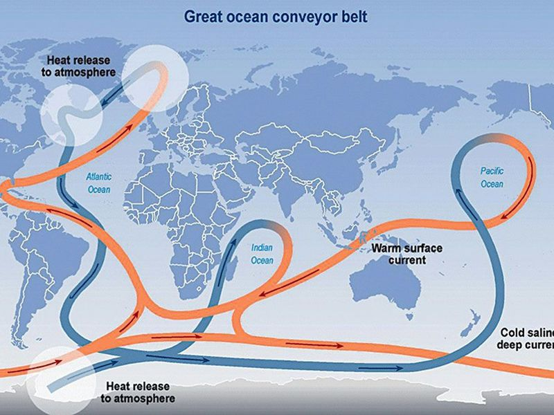

## Global climate: El Nino (https://www.climate.gov/enso)

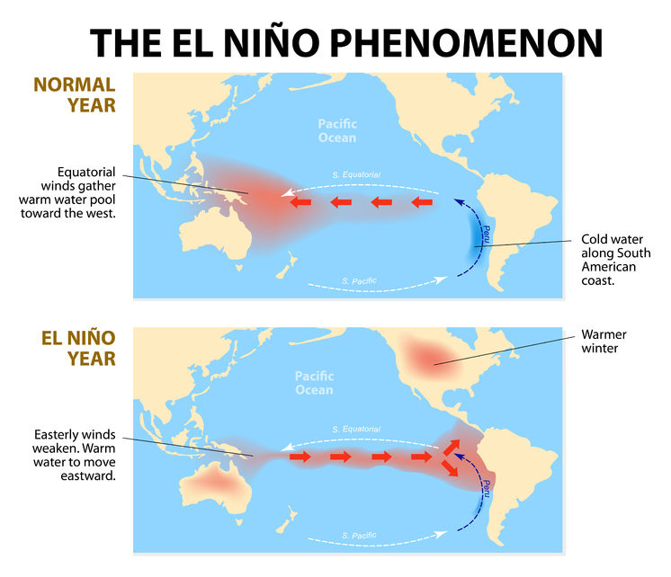

[figure not shown]

## Biomes: Defined by communities of plants w/ shared climate

[figure not shown]

## Climate envelopes define the boundaries of biomes

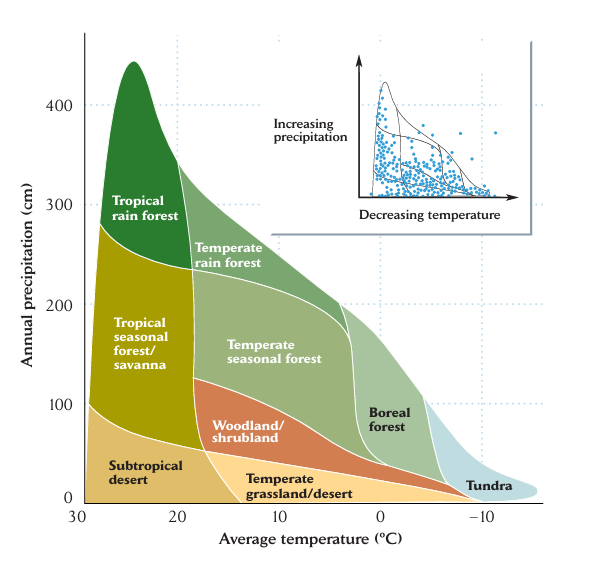

**Why is the yin and yang of ecology and evolution key here?**

## Biome Detective: Whittaker’s diagram is insufficient

- **Climate Sets the Stage — But It Doesn’t Tell the Whole Story**
  - Whittaker narrows the possibilities; ecological context resolves the ambiguity.
- **Seasonality: Same climates can produce very different conditions depending on when heat and water occur**
  - temperate forest vs grasslands
- **Fire/Disturbance: Climate may permit substantial tree cover, but fire can alter vegetation**
  - seasonal tropical forest vs savanna
- **Elevation: Regional climate might suggest one biome, but elevation creates colder local conditions**
  - boreal forest vs alpine tundra

## How does climate impact ecology? A question of scale…

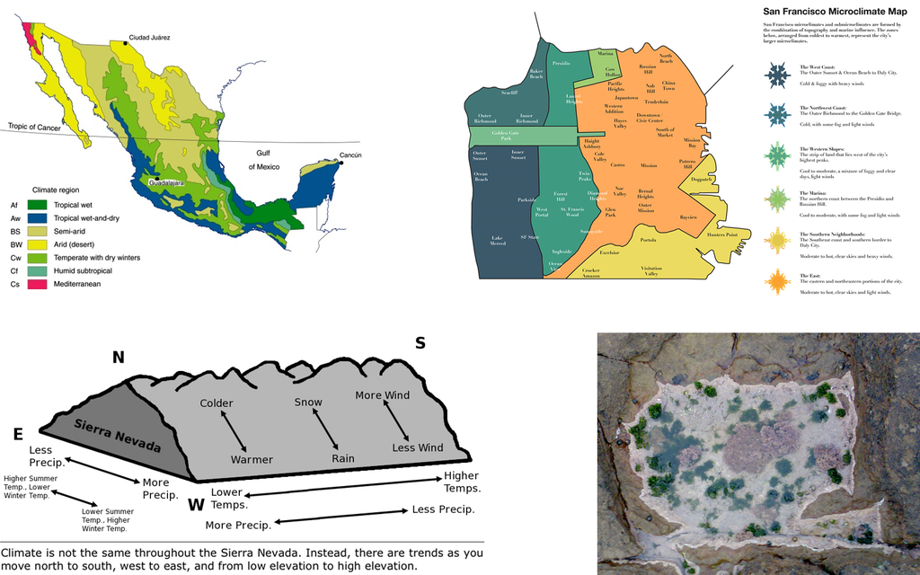

## Aquatic Biomes: Depth, light and nutrients

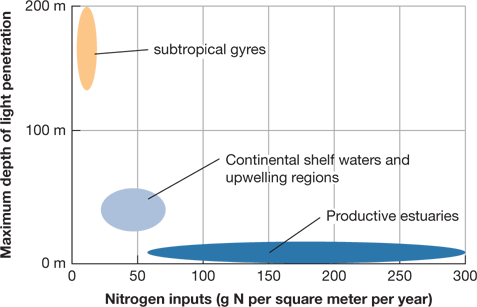

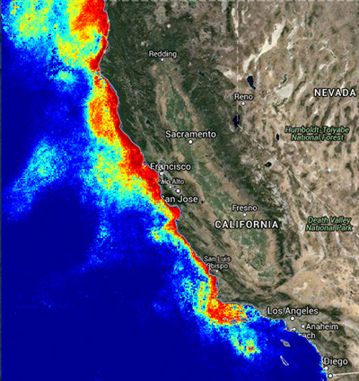

## Testable concepts in this lecture

- **Climate and weather are connected but should not be used interchangeably**
  - current vs collective atmospheric conditions
- **The Earth is round, tilted and spinning**
  - adds complexity to how energy interacts with the surface
  - more than just albedo
- **There are broad climate patterns with latitude and altitude**
- **HOWEVER - lots of other factors make weather and climate patterns more complex**
  - know some examples
- **Biomes = climate zones composed of living things adapted to specific climate conditions**
  - largely related to precipitation and temperature ranges